# Diagnose

Catherine

12/9/2018

# The model we selection

Import original dataset:

```r
final_fit = lm(formula = target_death_rate ~ incidence_rate + poverty_percent + median_age_female + region + pct_hs25_over + pct_unemployed16_over + pct_public_coverage + pct_black, data = data_vrb_pre_selec)
```

# plot the regression model

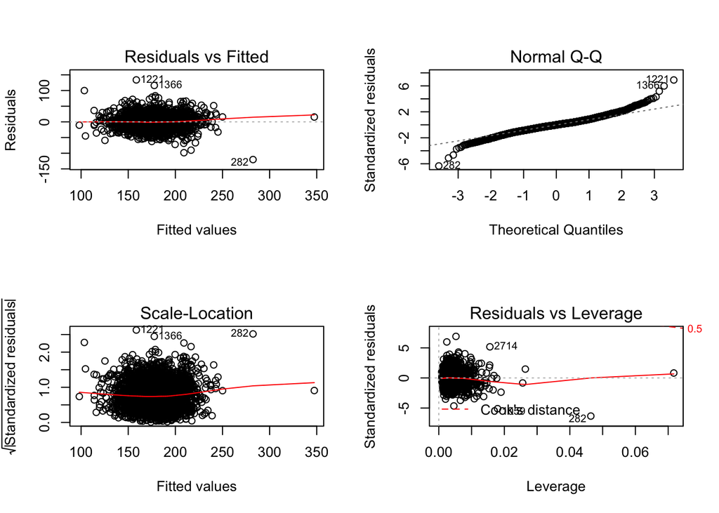

```r
par(mfrow = c(2,2))
plot(final_fit)
```

# Detect outliers in Y using ‘studentized residuals’

```r
sr = rstandard(final_fit) %>% as_tibble() %>% mutate(n = 1:3047)
outlier_y = sr %>% filter(abs(value) > 2.5)
names(outlier_y) = c("over_2.5", "observation_n")
knitr::kable(outlier_y, caption = "Outliers of y")
```

Outliers of y

| over_2.5 | observation_n |
| --- | --- |
| -2.827611 | 34 |
| -2.533002 | 69 |
| 4.302532 | 116 |
| 4.072685 | 122 |
| -2.536443 | 124 |
| 2.986257 | 166 |
| 2.550319 | 209 |
| 3.711303 | 254 |
| -3.093936 | 264 |
| -6.335868 | 282 |
| 2.589570 | 458 |
| 2.775789 | 466 |
| 3.176281 | 469 |
| 2.712182 | 472 |
| 2.665025 | 484 |
| 2.961596 | 522 |
| 3.498339 | 627 |
| -2.877339 | 650 |
| 3.057586 | 666 |
| 3.744594 | 775 |
| 3.007520 | 780 |
| -2.646955 | 783 |
| -3.066006 | 803 |
| -3.522056 | 812 |
| -2.738401 | 845 |
| -3.228826 | 912 |
| -2.605321 | 913 |
| -5.108314 | 1059 |
| 2.807535 | 1076 |
| 3.331022 | 1174 |
| 2.665904 | 1204 |
| 2.900443 | 1217 |
| 6.906951 | 1221 |
| 3.254849 | 1261 |
| 3.212963 | 1276 |
| 2.972752 | 1310 |
| -2.826130 | 1331 |
| -2.674014 | 1345 |
| 5.987311 | 1366 |
| -3.454702 | 1429 |
| -2.604152 | 1445 |
| 3.940797 | 1497 |
| -2.606555 | 1560 |
| -2.651861 | 1656 |
| -3.053804 | 1942 |
| 3.341980 | 2016 |
| 2.957788 | 2027 |
| -2.504754 | 2066 |
| 2.553310 | 2072 |
| 3.046156 | 2176 |
| -2.721390 | 2353 |
| -2.546154 | 2440 |
| -2.939336 | 2444 |
| 3.057881 | 2549 |
| 2.723730 | 2563 |
| 2.650640 | 2590 |
| -2.757403 | 2593 |
| 2.741504 | 2596 |
| 2.676102 | 2598 |
| 3.370048 | 2600 |
| -2.977887 | 2626 |
| 3.112307 | 2637 |
| -2.872019 | 2642 |
| -4.652908 | 2646 |
| -3.723104 | 2659 |
| -2.789767 | 2661 |
| 5.176288 | 2714 |
| 3.427660 | 2726 |
| 4.027745 | 2727 |
| -2.700396 | 2809 |
| 2.561375 | 2858 |
| 2.517872 | 3034 |

**Comment**

There are **72** ouliers in Y being detected.

# Detect outliners in X using Leverage values

```r
fit_hat = hatvalues(final_fit) %>% as_tibble() %>% mutate(n = 1:3047)
outlier_x_moderate = fit_hat %>% filter(abs(value) > 0.2)
outlier_x_high = fit_hat %>% filter(abs(value) > 0.5)
names(outlier_x_moderate) = c("over_0.2", "observation_n")
names(outlier_x_high) = c("over_0.5", "observation_n")
knitr::kable(outlier_x_moderate, caption = "Outliers of X (> 0.2)")
```

Table: Outliers of X (> 0.2)

over_0.2 observation_n ——— ————–

```r
knitr::kable(outlier_x_high, caption = "Outliers of X (> 2p/n)")
```

Table: Outliers of X (> 2p/n)

over_0.5 observation_n ——— ————–

**Comment**

By taking look at the $h_{ii}$ values, we detect **no oulier in X** with both cutoff $h_{ii} > 0.2$ and cutoff $h_{ii} > 0.5$.

# Influencial Observation

Not all outliers are influential. Therefore, we need to test the influence of the outliers. Using DFFITS test the difference of fitted value with/without an observation and Cook’s Distance to find concerned values.

```r
tb = influence.measures(final_fit)[["infmat"]] %>% as_tibble() %>%
  mutate(n = 1:3047) %>%
  dplyr::select(dffit, cook.d, n) %>%
  filter(abs(dffit)>1|abs(cook.d)>0.5)
knitr::kable(tb, caption = "Influential observation")
```

Influential observation

| dffit | cook.d | n |
| --- | --- | --- |
| -1.406687 | 0.177568 | 282 |

**Comment**

Consider `DFFITS` and `Cook's Distance`, we found out an influencitial outlier `282`. The difference is large between fitted value with/without `282` observation. Next, we can take a look at the change of fitted value with/without `282`.

```r
without282 = data_vrb_pre_selec[-282,]
fit_with282 = lm(formula = target_death_rate ~ incidence_rate + poverty_percent + median_age_female + region + pct_hs25_over + pct_unemployed16_over + pct_public_coverage + pct_black, data = data_vrb_pre_selec)
fit_without282 = lm(formula = target_death_rate ~ incidence_rate + poverty_percent + median_age_female + region + pct_hs25_over + pct_unemployed16_over + pct_public_coverage + pct_black, data = without282)

sum1 = summary(fit_with282)$coef
sum2 = summary(fit_without282)$coef

knitr::kable(sum1, caption = "Model with observation 282")
```

Model with observation 282

|  | Estimate | Std. Error | t value | Pr(>\|t\|) |
| --- | --- | --- | --- | --- |
| (Intercept) | 41.0158619 | 4.8519433 | 8.453492 | 0.0000000 |
| incidence_rate | 0.1987529 | 0.0068479 | 29.023944 | 0.0000000 |
| poverty_percent | 0.5035039 | 0.1129043 | 4.459564 | 0.0000085 |
| median_age_female | -0.5756659 | 0.1045375 | -5.506789 | 0.0000000 |
| regionNortheast | -9.0006727 | 1.4899651 | -6.040862 | 0.0000000 |
| regionSouth | 8.0247106 | 0.9310093 | 8.619367 | 0.0000000 |
| regionWest | -8.2577160 | 1.2660504 | -6.522423 | 0.0000000 |
| pct_hs25_over | 0.9853465 | 0.0613305 | 16.066184 | 0.0000000 |
| pct_unemployed16_over | 1.0042361 | 0.1503481 | 6.679406 | 0.0000000 |
| pct_public_coverage | 0.5819587 | 0.0979464 | 5.941603 | 0.0000000 |
| pct_black | -0.0910667 | 0.0326244 | -2.791373 | 0.0052813 |

```r
knitr::kable(sum2, caption = "Model without observation 282")
```

Model without observation 282

|  | Estimate | Std. Error | t value | Pr(>\|t\|) |
| --- | --- | --- | --- | --- |
| (Intercept) | 38.2892873 | 4.8394771 | 7.911865 | 0.0000000 |
| incidence_rate | 0.2076737 | 0.0069459 | 29.898691 | 0.0000000 |
| poverty_percent | 0.5249872 | 0.1122244 | 4.678012 | 0.0000030 |
| median_age_female | -0.5862357 | 0.1038744 | -5.643698 | 0.0000000 |
| regionNortheast | -9.2934420 | 1.4810374 | -6.274954 | 0.0000000 |
| regionSouth | 8.1157622 | 0.9250963 | 8.772884 | 0.0000000 |
| regionWest | -8.1496056 | 1.2579738 | -6.478359 | 0.0000000 |
| pct_hs25_over | 0.9649604 | 0.0610175 | 15.814492 | 0.0000000 |
| pct_unemployed16_over | 0.9846131 | 0.1494071 | 6.590136 | 0.0000000 |
| pct_public_coverage | 0.5748252 | 0.0973192 | 5.906599 | 0.0000000 |
| pct_black | -0.0977844 | 0.0324304 | -3.015208 | 0.0025893 |

```r
coef2 = (sum1[2]-sum2[2])/sum1[2]*100
coef3  = (sum1[3]-sum2[3])/sum1[3]*100
coef4 = (sum1[4]-sum2[4])/sum1[4]*100
coef5 = (sum1[5]-sum2[5])/sum1[5]*100
coef6 = (sum1[6]-sum2[6])/sum1[6]*100
coef7 = (sum1[7]-sum2[7])/sum1[7]*100
coef8 = (sum1[8]-sum2[8])/sum1[8]*100
coef9 = (sum1[9]-sum2[9])/sum1[9]*100
coef10 = (sum1[10]-sum2[10])/sum1[10]*100
coef11 = (sum1[11]-sum2[11])/sum1[11]*100

rbind(incidence_rate = coef2, log_poverty_percent = coef3, median_age_female = coef4, regionNortheast = coef5, regionSouth = coef6, regionWest = coef7, pct_hs18_24 = coef8, pct_hs25_over = coef9, pct_unemployed16_over = coef10, pct_public_coverage = coef11)
```

```
##                            [,1]
## incidence_rate        -4.488417
## log_poverty_percent   -4.266752
## median_age_female     -1.836114
## regionNortheast       -3.252749
## regionSouth           -1.134640
## regionWest             1.309204
## pct_hs18_24            2.068923
## pct_hs25_over          1.954016
## pct_unemployed16_over  1.225767
## pct_public_coverage   -7.376641
```

**Comment**

After calculating the coefficient changes for each variables, we found that the changes are not significant. We decided to keep the observation `282` in our model.

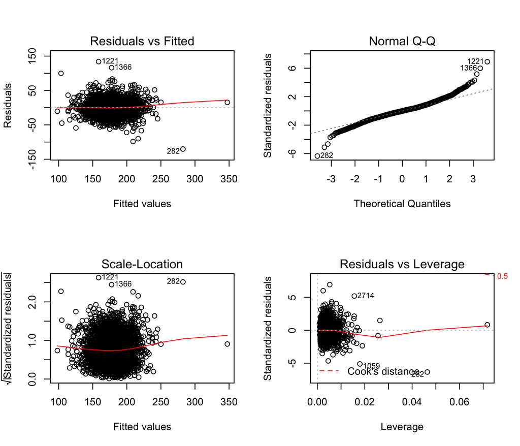

```r
fit_with282 = lm(formula = target_death_rate ~ incidence_rate + poverty_percent + median_age_female + region + pct_hs25_over + pct_unemployed16_over + pct_public_coverage + pct_black, data = data_vrb_pre_selec)

par(mfrow = c(2,2))
plot(fit_with282)
```

**Comment**

In the *Residuals vs Fitted Plot* and *Scale-Location Plot*, residual values are roughly bounce around 0.

# Multicolinearity

```r
cor_fit = data_vrb_pre_selec %>%
  dplyr::select(target_death_rate, incidence_rate, poverty_percent, median_age_female, pct_hs25_over, pct_unemployed16_over, pct_public_coverage, pct_black)

round(cor(cor_fit),3) %>% knitr::kable()
```

|  | target_death_rate | incidence_rate | poverty_percent | median_age_female | pct_hs25_over | pct_unemployed16_over | pct_public_coverage | pct_black |
| --- | --- | --- | --- | --- | --- | --- | --- | --- |
| target_death_rate | 1.000 | 0.449 | 0.429 | 0.012 | 0.405 | 0.378 | 0.405 | 0.257 |
| incidence_rate | 0.449 | 1.000 | 0.009 | -0.009 | 0.122 | 0.100 | 0.046 | 0.113 |
| poverty_percent | 0.429 | 0.009 | 1.000 | -0.148 | 0.194 | 0.655 | 0.651 | 0.512 |
| median_age_female | 0.012 | -0.009 | -0.148 | 1.000 | 0.345 | -0.111 | 0.455 | -0.157 |
| pct_hs25_over | 0.405 | 0.122 | 0.194 | 0.345 | 1.000 | 0.082 | 0.428 | -0.024 |
| pct_unemployed16_over | 0.378 | 0.100 | 0.655 | -0.111 | 0.082 | 1.000 | 0.530 | 0.469 |
| pct_public_coverage | 0.405 | 0.046 | 0.651 | 0.455 | 0.428 | 0.530 | 1.000 | 0.196 |
| pct_black | 0.257 | 0.113 | 0.512 | -0.157 | -0.024 | 0.469 | 0.196 | 1.000 |

```r
vif(fit_with282)
```

```
##        incidence_rate       poverty_percent     median_age_female
##              1.125278              4.220839              2.467793
##       regionNortheast           regionSouth            regionWest
##              1.184081              1.732474              1.529861
##         pct_hs25_over pct_unemployed16_over   pct_public_coverage
##              1.500572              2.171783              4.755406
##             pct_black
##              1.812475
```

**Comments**

By checking Correlation Matrix and vif value of each varibles, we found no correlation over 0.7 and no vif over 5. The variables we chose are significant.